# Progress Memo 2

Final Project  
Data Science 1 with R (STAT 301-1)

Author

Jeremy Ferguson

Published

December 7, 2023

**Github Repo Link**

https://github.com/stat301-1-2023-fall/final-project-1-jeremyferg.git

## Overview

In my project, I wish to analyze the correlation between stocks of video game publishers and industry-related events occurring over the past 10 years.

The majority of the complexity of my project comes from the way I retrieve and clean my data. I decided to web scrape video game information from Wikipedia pages, past Game Awards results from Wikipedia pages, and critic reviews from OpenCritic. With my web-scrapped data frames, combined with a few pre-existing data frames, my original goal was to create one large time series data frame. Since then, these objectives have changed slightly while still maintaining an appropriate level of complexity.

I have spent my time creating web-scraping functions that can find my specified information. Specifically, I have made significant progress on web scrapping general game information, game reviews, and game awards. Each of the R scripts for these functions is located in the `webscraping_scripts` folder of my GitHub.

## Web Scraping

### game_info

Web scrapping game information was my first and certainly hardest function to create. All of the general information I needed for each game was conveniently in the info box on each game’s Wikipedia page. However, the structure of these tables was not entirely uniform. Publishers and release dates gave me (and still are giving me) the most problems. Concerning release dates, many had different formatting or were embedded in other text. Also, many games have multiple release dates, depending on a player’s region. I decided to extract the first date string from the page and drop the other dates, which I believe still gives me enough information for thorough analysis. I had a similar issue arise with publishers, adding the problem that some publishers are linked in the table while others are not. I chose to try and capture every publisher involved in the game’s creation. I’m still working on completely parsing out all relevant information.

We can see how my functions clean video game information by using Crysis 3, a 2013 first-person-shooter, as an example:

First, `get_games_info()` extracts the specified data from the Wikipedia page. This function also separates distinct genres and modes into different rows.

| name | publishers | series | release | genres | modes |
| --- | --- | --- | --- | --- | --- |
| Crysis_3 | .mw-parser-output .plainlist ol,.mw-parser-output .plainlist ul{line-height:inherit;list-style:none;margin:0;padding:0}.mw-parser-output .plainlist ol li,.mw-parser-output .plainlist ul li{margin-bott… | Crysis | NA: 19 February 2013AU: 21 February 2013EU: 22 February 2013RemasteredWW: 15 October 2021 | First-person shooter | Single-player |
| Crysis_3 | .mw-parser-output .plainlist ol,.mw-parser-output .plainlist ul{line-height:inherit;list-style:none;margin:0;padding:0}.mw-parser-output .plainlist ol li,.mw-parser-output .plainlist ul li{margin-bott… | Crysis | NA: 19 February 2013AU: 21 February 2013EU: 22 February 2013RemasteredWW: 15 October 2021 | First-person shooter | multiplayer |

`release_extractor()` finds the first release date and makes this charcater type date.

| name | publishers | series | release | genres | modes |
| --- | --- | --- | --- | --- | --- |
| Crysis_3 | .mw-parser-output .plainlist ol,.mw-parser-output .plainlist ul{line-height:inherit;list-style:none;margin:0;padding:0}.mw-parser-output .plainlist ol li,.mw-parser-output .plainlist ul li{margin-bott… | Crysis | 2013-02-19 | First-person shooter | Single-player |
| Crysis_3 | .mw-parser-output .plainlist ol,.mw-parser-output .plainlist ul{line-height:inherit;list-style:none;margin:0;padding:0}.mw-parser-output .plainlist ol li,.mw-parser-output .plainlist ul li{margin-bott… | Crysis | 2013-02-19 | First-person shooter | multiplayer |

`publisher_cleaner()` finds all publishers.

| name | publishers | series | release | genres | modes |
| --- | --- | --- | --- | --- | --- |
| Crysis_3 | crytek | Crysis | 2013-02-19 | First-person shooter | Single-player |
| Crysis_3 | electronic arts | Crysis | 2013-02-19 | First-person shooter | Single-player |
| Crysis_3 | crytek | Crysis | 2013-02-19 | First-person shooter | multiplayer |
| Crysis_3 | electronic arts | Crysis | 2013-02-19 | First-person shooter | multiplayer |

Looping over these functions for each game gives us the current `game_info` data frame, which has 8692 observations, (tentatively) has 4524 unique games, and 204 unique publishers.

### game_awards

The challenge with the Game Awards data was restructuring the data. Reading the table directly from Wikipedia created a very disorganized data frame, which I was able to successfully manipulate and clean. One function gets the Game Awards for a given year. Note, that while the nominees have been released for the 2023 Game Awards, the ceremony does not happen until December. So, these observations are not in my data frame.

Here is an example of using the function `game_awards_2016_2022()` to find 2016 data. For conciseness, I only printed the first 10 observations:

| category | game | publisher | winner | date |
| --- | --- | --- | --- | --- |
| Best Game Direction | Overwatch | Blizzard Entertainment‡ | TRUE | 2016-12-01 |
| Best Game Direction | Battlefield 1 | EA DICE | FALSE | 2016-12-01 |
| Best Game Direction | Doom | id Software | FALSE | 2016-12-01 |
| Best Game Direction | Titanfall 2 | Respawn Entertainment | FALSE | 2016-12-01 |
| Best Game Direction | Uncharted 4: A Thief’s End | Naughty Dog | FALSE | 2016-12-01 |
| Best Art Direction | Inside | Playdead‡ | TRUE | 2016-12-01 |
| Best Art Direction | Abzû | Giant Squid | FALSE | 2016-12-01 |
| Best Art Direction | Firewatch | Campo Santo | FALSE | 2016-12-01 |
| Best Art Direction | Overwatch | Blizzard Entertainment | FALSE | 2016-12-01 |
| Best Art Direction | Uncharted 4: A Thief’s End | Naughty Dog | FALSE | 2016-12-01 |

Overall we have 1420 observations with 56 unique categories and 578 unique games.

### game_reviews

At first, I wanted to scrape data from Metacritic, which has both critic scores and user scores. However, I had a very difficult time trying to extract this data, which I believe to be because Metacritic is a dynamic site. Instead, I scraped critic scores from OpenCritic. Though I lost the ability to scrape user data, using OpenCritic made the web scrapping process much more manageable.

Again, here is an example of my functions for `game_reviews` in use using critic reviews for Elden Ring:

`ratings_date_tibble()` gets the raw data for a given game.

| reviewer | review_company | rating | date |
| --- | --- | --- | --- |
| Mitchell Saltzman | IGN | 10 / 10.0 | Feb 23, 2022 |
| Tyler Colp | PC Gamer | 90 / 100 | Feb 23, 2022 |
| GameCentral | Metro GameCentral | 9 / 10 | Feb 23, 2022 |
| Brad Ellis | Easy Allies | 9.5 / 10.0 | Feb 23, 2022 |
| Daniel Tack | Game Informer | 10 / 10.0 | Feb 23, 2022 |
| Tamoor Hussain | GameSpot | 10 / 10 | Mar 16, 2022 |
| Chris Carter | Destructoid | 10 / 10.0 | Feb 23, 2022 |
| Jason Faulkner | Game Revolution | 10 / 10.0 | Feb 23, 2022 |
| Cristian M. Villa | Areajugones | 10 / 10.0 | Feb 23, 2022 |
| Álvaro Alonso | Hobby Consolas | 98 / 100 | Feb 23, 2022 |

Next, I find `game` and make several mutations to `rating`, `date`, and `reviewer`.

| date | game | reviewer | review_company | rating |
| --- | --- | --- | --- | --- |
| 2021-01-28 | elden_ring | Alex Tudor | Digital Chumps | 100 |
| 2022-02-23 | elden_ring | Mitchell Saltzman | IGN | 100 |
| 2022-02-23 | elden_ring | Tyler Colp | PC Gamer | 90 |
| 2022-02-23 | elden_ring | GameCentral | Metro GameCentral | 90 |
| 2022-02-23 | elden_ring | Brad Ellis | Easy Allies | 95 |
| 2022-02-23 | elden_ring | Daniel Tack | Game Informer | 100 |
| 2022-02-23 | elden_ring | Chris Carter | Destructoid | 100 |
| 2022-02-23 | elden_ring | Jason Faulkner | Game Revolution | 100 |
| 2022-02-23 | elden_ring | Cristian M. Villa | Areajugones | 100 |
| 2022-02-23 | elden_ring | Álvaro Alonso | Hobby Consolas | 98 |

Lastly, I find the average critic score for the game on the previous day, `avg_rating_yesterday()`.

| date | game | reviewer | review_company | rating | rating_yesterday |
| --- | --- | --- | --- | --- | --- |
| 2021-01-28 | elden_ring | Alex Tudor | Digital Chumps | 100 | 0 |
| 2022-02-23 | elden_ring | Mitchell Saltzman | IGN | 100 | 100 |
| 2022-02-23 | elden_ring | Tyler Colp | PC Gamer | 90 | 100 |
| 2022-02-23 | elden_ring | GameCentral | Metro GameCentral | 90 | 100 |
| 2022-02-23 | elden_ring | Brad Ellis | Easy Allies | 95 | 100 |
| 2022-02-23 | elden_ring | Daniel Tack | Game Informer | 100 | 100 |
| 2022-02-23 | elden_ring | Chris Carter | Destructoid | 100 | 100 |
| 2022-02-23 | elden_ring | Jason Faulkner | Game Revolution | 100 | 100 |
| 2022-02-23 | elden_ring | Cristian M. Villa | Areajugones | 100 | 100 |
| 2022-02-23 | elden_ring | Álvaro Alonso | Hobby Consolas | 98 | 100 |

Overall, `game_reviews` holds 163962 observations from 7998 reviewers and 494 review companies.

## Relational Database Design

While I can make one large time series data frame, this data frame would be incredibly long with a lot of redundant information. I found creating a relational database design that easily separates key variables while making clear relationships with each variable would prove to be more appropriate for this project. The PNG file showing this design is located in the `data` folder of my GitHub. I have also printed the design here:

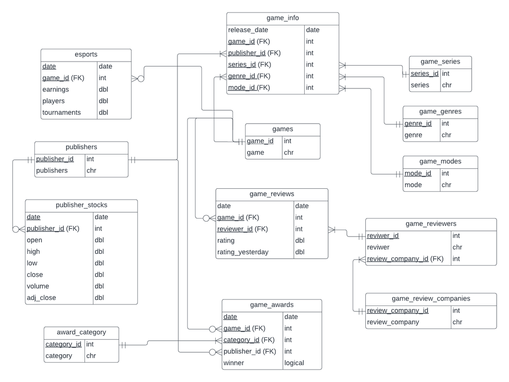

`game_info` can be used to find the ids for variables `game_id`, `publisher_id`, `series_id`, `genre_id`, and `mode_id` by finding the distinct values of each of the respective variables. I am assuming that `game_name` will correctly match with game names in the raw version of `game_awards`, `game_reviews`, and `esports` so I can easily add `game_id` to these tables as foreign keys. After adding the id, the actual name of the game will be dropped to address redundancy across tables. The same assumption applies to publisher names with `publishers` and `publisher_stocks`, but I would be able to resolve this issue much easier given I am only looking at 10 different company stocks. `category_id`, `review_company_id`, and `reviewer_id` should also be easy to create, given we have full information about each of these variables.

## Final Thoughts

By the 2nd memo, I wanted to at least have my web-scraped data frames completely cleaned and have my EDA started. That goal proved to be a bit ambitious of me, as I found myself dealing with multiple issues when making functions. The functions I created certainly can be made more efficient, and I plan to explore ways to tidy the functions. However, I think the techniques I used are a nice reflection of the skills I gained from this course. I still think I’m in a good position for this project. I originally wanted to shoot for an early submission, and, while it may take some serious time and effort, I think I can still accomplish that goal. Through all the issues, I have enjoyed learning this new skill and would love to continue refining it in future personal or class projects.